# Dates & Times in R

Working with datetimes and `lubridate`

### Learning Objectives

- Learn the basic date/datetime types in R
- Gain familarity with converting dates and timezones
- Learn how to use the `lubridate` package
- Tips and tricks about management of datetime data

# Date-Times in R

We have learned about different data type classes in previous lessons. Some common data classes we have examined before include character, factor, and numeric. But R also recognizes a data class called “Dates”. Having your date data in the “Dates” data class is very useful, as you can then do things like calculate time between two events, transform the dates into different formats, and plot temporal data easily. In this lesson, we are going to introduce how base R deals with dates (`POSIXct` or `POSITlt`), but we are going to spend the majority of our lesson on the package `lubridate`. `lubridate` is a great package that makes it much easier to work with dates and times in R.

## Date-Time Classes in Base R

Importantly, there are **3** basic time classes in R:

- **`Dates`** (just dates, i.e., 2012-02-10)
- **`POSIXct`** (“**ct**” == calendar time, best class for dates with times)
- **`POSIXlt`** (“**lt**” == local time, enables easy extraction of specific components of a time, however, remember that POXIXlt objects are lists)

Unfortunately converting dates & times in R into formats that are computer readable can be frustrating, mainly because there is very little consistency. In particular, if you are importing things from Excel, keep in mind dates can get especially weird<sup>1</sup>, depending on the operating system you are working on, the format of your data, etc.

<sup>*1*</sup> <sub>*For example Excel stores dates as a number representing days since 1900-Jan-0, plus a fractional portion of a 24 hour day (**serial-time**), but in OSX (Mac), it is 1904-Jan-0.*</sub>

## Dates

The `Date` class in R can easily be converted or operated on numerically, depending on the interest. Let’s make a string of dates to use for our example:

```r
sample_dates_1 <- c("2018-02-01", "2018-03-21", "2018-10-05", "2019-01-01", "2019-02-18")
#notice we have dates across two years here
```

What is the class that R classifies this data as?

R classifies our `sample_dates_1` data as character data. Let’s transform it into Dates. Notice that our `sample_dates_1` is in a nice formate: YYYY-MM-DD. This is the format necessary for the function `as.Date`.

```r
sample_dates_1 <- as.Date(sample_dates_1)
```

What happens with different orders…say MM-DD-YYYY?

```r
# Some sample dates:

sample_dates_2 <- c("02-01-2018", "03-21-2018", "10-05-2018", "01-01-2019", "02-18-2019")

sample_dates_3 <-as.Date(sample_dates_2) # well that doesn't work
```

The reason this doesn’t work is because the computer expects one thing, but is getting something else. Remember, **write code you can read and your computer can understand**. So we need to give some more information here so R will interpret our data correctly.

```r
# Some sample dates:
sample_dates_2 <- c("02-01-2018", "03-21-2018", "10-05-2018", "01-01-2019", "02-18-2019")

sample_dates_3<- as.Date(sample_dates_2, format = "%m-%d-%Y" ) # date code preceded by "%"
```

To see a list of the date-time format codes in R, check out this [page and table](https://www.stat.berkeley.edu/~s133/dates.html), or you can use: `?(strptime)`

The nice thing is this method works well with pretty much any format, you just need to provide the associated codes and structure:

- `as.Date("2016/01/01", format="%Y/%m/%d")`=2016-01-01
- `as.Date("05A21A2011", format="%mA%dA%Y")`=2011-05-21

### Challenge

Format this date with the `as.Date` function: `Jul 04, 2019`

**ANSWER**

```r
as.Date("Jul 04, 2019", format = "%b%d,%Y")
```

```
## [1] "2019-07-04"
```

## Working with Times in Base R

When working with times, the best class to use in base R is `POSIXct`.

```r
tm1 <- as.POSIXct("2016-07-24 23:55:26")
tm1
```

```
## [1] "2016-07-24 23:55:26 PDT"
```

```r
tm2 <- as.POSIXct("25072016 08:32:07", format = "%d%m%Y %H:%M:%S")
tm2
```

```
## [1] "2016-07-25 08:32:07 PDT"
```

```r
#Notice how POSIXct automatically uses the timezone your computer is set to. What if we collected this data in a different timezone?

# specify the time zone:
tm3 <- as.POSIXct("2010-12-01 11:42:03", tz = "GMT")
tm3
```

```
## [1] "2010-12-01 11:42:03 GMT"
```

# The `lubridate` Package

The `lubridate` package will handle 90% of the date & datetime issues you need to deal with. It is fast, much easier to work with, and we recommend using it wherever possible. Do keep in mind sometimes you need to fall back on the base R functions (i.e., `as.Date()`), which is why having a basic understanding of theses functions and their use is important.

To use `lubridate` we will first need to install and load the package.

```r
#install.packages("lubridate")

library(lubridate)
```

`lubridate` has lots of handy functions for converting between date and time formats, and even timezones.

Let’s take a look at our `sample_dates_1` data again.

```r
sample_dates_1 <- c("2018-02-01", "2018-03-21", "2018-10-05", "2019-01-01", "2019-02-18")
```

Once again, R reads this in a character data.

Lubridate uses functions that looks like `ymd` or `mdy` to transform data into the class “Date”. Our `sample_dates_1` data is formated like Year, Month, Day, so we would use the `lubridate` function `ymd` (y = year, m = month, d = day).

```r
sample_dates_lub <- ymd(sample_dates_1)
```

What about that messier `sample_dates_2` data? Remember R wants dates to be in the format YYYY-MM-DD.

```r
sample_dates_2 <- c("2-01-2018", "3-21-2018", "10-05-18", "01-01-2019", "02-18-2019")
#notice that some numbers for years and months are missing

sample_dates_lub2 <- mdy(sample_dates_2) #lubridate can handle it!
```

All sorts of date formats can eaisly be transformed using `lubridate`:

- `lubridate::ymd("2016/01/01")`=2016-01-01
- `lubridate::ymd("2011-03-19")`=2011-03-19
- `lubridate::mdy("Feb 19, 2011")`=2011-02-19
- `lubridate::dmy("22051997")`=1997-05-22

## Using `lubridate` for Time and Timezones

`lubridate` has very similar functions to handle data with Times and Timezones. To the `ymd` function, add `_hms` or `_hm` (h= hours, m= minute, s= seconds) and a `tz` arguement. `lubridate` will default to the POSIXct format.

- Example 1: `lubridate::ymd_hm("2016-01-01 12:00", tz="America/Los_Angeles")` = 2016-01-01 12:00:00
- Example 2 (24 hr time): `lubridate::ymd_hm("2016/04/05 14:47", tz="America/Los_Angeles")` = 2016-04-05 14:47:00
- Example 3 (12 hr time but converts to 24): `lubridate::ymd_hms("2016/04/05 4:47:21 PM", tz="America/Los_Angeles")` = 2016-04-05 16:47:21

#### Lubridate Tips

For lubridate to work, you need the column datatype to be **character** or **factor**. The `readr` package (from the `tidyverse`) is smart and will try to guess for you. Problem is, it might convert your data for you without the settings (in this case the proper timezone). So here are few ways to work around this.

```r
library(lubridate)
library(dplyr)
library(readr)

# read in some data and skip header lines
nfy1 <- read_csv("../data/2015_NFY_solinst.csv", skip = 12)
head(nfy1) #R tried to guess for you that the first column was a date and the second a time
```

```
## # A tibble: 6 x 5
##   Date       Time      ms Level Temperature
##   <date>     <time> <dbl> <dbl>       <dbl>
## 1 2015-05-22 14:00      0 -8.68           0
## 2 2015-05-22 14:15      0 -8.29           0
## 3 2015-05-22 14:30      0 -8.29           0
## 4 2015-05-22 14:45      0 -8.29           0
## 5 2015-05-22 15:00      0 -8.30           0
## 6 2015-05-22 15:15      0 -8.29           0
```

```r
# import raw dataset & specify column types
nfy2 <- read_csv("../data/2015_NFY_solinst.csv", col_types = "ccidd", skip=12)

glimpse(nfy1) # notice the data types in the Date.Time and datetime cols
```

```
## Observations: 7,764
## Variables: 5
## $ Date        <date> 2015-05-22, 2015-05-22, 2015-05-22, 2015-05-22, 2...
## $ Time        <time> 14:00:00, 14:15:00, 14:30:00, 14:45:00, 15:00:00,...
## $ ms          <dbl> 0, 0, 0, 0, 0, 0, 0, 0, 0, 0, 0, 0, 0, 0, 0, 0, 0,...
## $ Level       <dbl> -8.6834, -8.2928, -8.2914, -8.2901, -8.2955, -8.29...
## $ Temperature <dbl> 0, 0, 0, 0, 0, 0, 0, 0, 0, 0, 0, 0, 0, 0, 0, 0, 0,...
```

```r
glimpse(nfy2)
```

```
## Observations: 7,764
## Variables: 5
## $ Date        <chr> "2015/05/22", "2015/05/22", "2015/05/22", "2015/05...
## $ Time        <chr> "14:00:00", "14:15:00", "14:30:00", "14:45:00", "1...
## $ ms          <int> 0, 0, 0, 0, 0, 0, 0, 0, 0, 0, 0, 0, 0, 0, 0, 0, 0,...
## $ Level       <dbl> -8.6834, -8.2928, -8.2914, -8.2901, -8.2955, -8.29...
## $ Temperature <dbl> 0, 0, 0, 0, 0, 0, 0, 0, 0, 0, 0, 0, 0, 0, 0, 0, 0,...
```

```r
# make a datetime col:
nfy2$datetime <- paste(nfy2$Date, " ", nfy2$Time, sep = "")

glimpse(nfy2) #notice the  datetime column is classifed as character
```

```
## Observations: 7,764
## Variables: 6
## $ Date        <chr> "2015/05/22", "2015/05/22", "2015/05/22", "2015/05...
## $ Time        <chr> "14:00:00", "14:15:00", "14:30:00", "14:45:00", "1...
## $ ms          <int> 0, 0, 0, 0, 0, 0, 0, 0, 0, 0, 0, 0, 0, 0, 0, 0, 0,...
## $ Level       <dbl> -8.6834, -8.2928, -8.2914, -8.2901, -8.2955, -8.29...
## $ Temperature <dbl> 0, 0, 0, 0, 0, 0, 0, 0, 0, 0, 0, 0, 0, 0, 0, 0, 0,...
## $ datetime    <chr> "2015/05/22 14:00:00", "2015/05/22 14:15:00", "201...
```

```r
# convert Date Time to POSIXct in local timezone using lubridate
nfy2$datetime_test <- as_datetime(nfy2$datetime,
                                    tz="America/Los_Angeles")
# OR convert using the ymd_functions
nfy2$datetime_test2 <- ymd_hms(nfy2$datetime, tz="America/Los_Angeles")

# OR wrap in as.character()
nfy1$datetime <- ymd_hms(as.character(paste0(nfy1$Date," ", nfy1$Time)), tz="America/Los_Angeles")
tz(nfy1$datetime)
```

```
## [1] "America/Los_Angeles"
```

## Example 1: Mauna Loa Meterological Data

So, now that we have a decent idea how to format these things, let’s look at some real data, try to format and plot. Let’s use the Mauna Loa meterological data, collected every minute for the year 2001. *This dataset has 459,769 observations for 9 different metrics of wind, humidity, barometric pressure, air temperature, and precipitation.* Download this dataset here. Save it to your `data/` folder. Alternatively, you can find it on the R-DAVIS website in the [Resources->Datasets](https://gge-ucd.github.io/R-DAVIS/resources.html) tab.

```r
mloa <- readRDS("../data/mauna_loa_met_2001_minute.rds")

library(lubridate, warn.conflicts = F)
library(dplyr, warn.conflicts = F)

summary(mloa)
```

```
##    filename         siteID            year          month
##  Length:459769      MLO:459769   Min.   :2001   Min.   : 1.000
##  Class :character                1st Qu.:2001   1st Qu.: 3.000
##  Mode  :character                Median :2001   Median : 6.000
##                                  Mean   :2001   Mean   : 6.474
##                                  3rd Qu.:2001   3rd Qu.:10.000
##                                  Max.   :2001   Max.   :12.000
##       day            hour24           min           windDir
##  Min.   : 1.00   Min.   : 0.00   Min.   : 0.00   Min.   :-999.0
##  1st Qu.: 8.00   1st Qu.: 5.00   1st Qu.:15.00   1st Qu.: 115.0
##  Median :15.00   Median :11.00   Median :30.00   Median : 156.0
##  Mean   :15.44   Mean   :11.43   Mean   :29.51   Mean   : 144.5
##  3rd Qu.:22.00   3rd Qu.:18.00   3rd Qu.:45.00   3rd Qu.: 236.0
##  Max.   :31.00   Max.   :23.00   Max.   :59.00   Max.   : 360.0
##  windSpeed_m_s       windSteady    baro_hPa        temp_C_2m
##  Min.   :-99.900   Min.   :-9   Min.   :-999.9   Min.   :-999.900
##  1st Qu.:  1.900   1st Qu.:-9   1st Qu.:-999.9   1st Qu.:   4.400
##  Median :  3.500   Median :-9   Median :-999.9   Median :   6.900
##  Mean   :  1.229   Mean   :-9   Mean   :-999.9   Mean   :   4.747
##  3rd Qu.:  5.900   3rd Qu.:-9   3rd Qu.:-999.9   3rd Qu.:   9.400
##  Max.   : 20.500   Max.   :-9   Max.   :-999.9   Max.   :  18.900
##    temp_C_10m      temp_C_towertop      rel_humid      precip_intens_mm_hr
##  Min.   :-999.90   Min.   :-999.900   Min.   :-99.00   Min.   :-99.0000
##  1st Qu.:   4.90   1st Qu.:   5.600   1st Qu.: 14.00   1st Qu.:  0.0000
##  Median :   6.90   Median :   7.200   Median : 28.00   Median :  0.0000
##  Mean   : -46.69   Mean   :   1.539   Mean   : 31.82   Mean   : -0.8066
##  3rd Qu.:   8.60   3rd Qu.:   8.800   3rd Qu.: 57.00   3rd Qu.:  0.0000
##  Max.   :  16.90   Max.   :  16.200   Max.   :138.00   Max.   : 60.0000
```

```r
names(mloa)
```

```
##  [1] "filename"            "siteID"              "year"
##  [4] "month"               "day"                 "hour24"
##  [7] "min"                 "windDir"             "windSpeed_m_s"
## [10] "windSteady"          "baro_hPa"            "temp_C_2m"
## [13] "temp_C_10m"          "temp_C_towertop"     "rel_humid"
## [16] "precip_intens_mm_hr"
```

One of the important components to consider is each of the datetime columns has been separated…so how do we get them into one column so we can format it as a datetime? The answer is the `paste` function.

```r
# we need to make a datetime column...let's use paste
mloa$datetime <- paste0(mloa$year,"-", mloa$month, "-", mloa$day," ", mloa$hour24, ":", mloa$min) # this makes a character column

head(mloa$datetime) # character vector but not POSIXct yet
```

```
## [1] "2001-1-1 0:0" "2001-1-1 0:1" "2001-1-1 0:2" "2001-1-1 0:3"
## [5] "2001-1-1 0:4" "2001-1-1 0:5"
```

```r
# we can nest this within a lubridate function to convert directly to POSIXct
mloa$datetime <- ymd_hm(mloa$datetime, tz="Pacific/Honolulu")

# OR all in one step
mloa$datetime <- ymd_hm(paste0(mloa$year,"-", mloa$month, "-", mloa$day," ", mloa$hour24, ":", mloa$min), tz = "Pacific/Honolulu")

summary(mloa) # notice a new column called "datetime"
```

```
##    filename         siteID            year          month
##  Length:459769      MLO:459769   Min.   :2001   Min.   : 1.000
##  Class :character                1st Qu.:2001   1st Qu.: 3.000
##  Mode  :character                Median :2001   Median : 6.000
##                                  Mean   :2001   Mean   : 6.474
##                                  3rd Qu.:2001   3rd Qu.:10.000
##                                  Max.   :2001   Max.   :12.000
##       day            hour24           min           windDir
##  Min.   : 1.00   Min.   : 0.00   Min.   : 0.00   Min.   :-999.0
##  1st Qu.: 8.00   1st Qu.: 5.00   1st Qu.:15.00   1st Qu.: 115.0
##  Median :15.00   Median :11.00   Median :30.00   Median : 156.0
##  Mean   :15.44   Mean   :11.43   Mean   :29.51   Mean   : 144.5
##  3rd Qu.:22.00   3rd Qu.:18.00   3rd Qu.:45.00   3rd Qu.: 236.0
##  Max.   :31.00   Max.   :23.00   Max.   :59.00   Max.   : 360.0
##  windSpeed_m_s       windSteady    baro_hPa        temp_C_2m
##  Min.   :-99.900   Min.   :-9   Min.   :-999.9   Min.   :-999.900
##  1st Qu.:  1.900   1st Qu.:-9   1st Qu.:-999.9   1st Qu.:   4.400
##  Median :  3.500   Median :-9   Median :-999.9   Median :   6.900
##  Mean   :  1.229   Mean   :-9   Mean   :-999.9   Mean   :   4.747
##  3rd Qu.:  5.900   3rd Qu.:-9   3rd Qu.:-999.9   3rd Qu.:   9.400
##  Max.   : 20.500   Max.   :-9   Max.   :-999.9   Max.   :  18.900
##    temp_C_10m      temp_C_towertop      rel_humid      precip_intens_mm_hr
##  Min.   :-999.90   Min.   :-999.900   Min.   :-99.00   Min.   :-99.0000
##  1st Qu.:   4.90   1st Qu.:   5.600   1st Qu.: 14.00   1st Qu.:  0.0000
##  Median :   6.90   Median :   7.200   Median : 28.00   Median :  0.0000
##  Mean   : -46.69   Mean   :   1.539   Mean   : 31.82   Mean   : -0.8066
##  3rd Qu.:   8.60   3rd Qu.:   8.800   3rd Qu.: 57.00   3rd Qu.:  0.0000
##  Max.   :  16.90   Max.   :  16.200   Max.   :138.00   Max.   : 60.0000
##     datetime
##  Min.   :2001-01-01 00:00:00
##  1st Qu.:2001-03-29 06:57:00
##  Median :2001-06-24 06:13:00
##  Mean   :2001-06-30 15:28:42
##  3rd Qu.:2001-10-07 00:34:00
##  Max.   :2001-12-31 23:59:00
```

```r
head(mloa$datetime) # in POSIXct
```

```
## [1] "2001-01-01 00:00:00 HST" "2001-01-01 00:01:00 HST"
## [3] "2001-01-01 00:02:00 HST" "2001-01-01 00:03:00 HST"
## [5] "2001-01-01 00:04:00 HST" "2001-01-01 00:05:00 HST"
```

### Challenge with `dplyr` and `ggplot`

Let’s plot some of the Mauna Loa data we just downloaded. First, removed the NAs (here designated with -99.9 and -999.9) in `rel_humid`, `temp_C_2m`, and `windSpeed_m_s`. Next, use `dplyr` to calculate the mean monthly temperature using the `temp_C_2m` column and the `datetime` column. (*HINT: Look at the lubridate function called `month()`). Finally, make a ggplot of the mean monthly temperature.

EXTRA CHALLENGE: Make a ggplot of the average hourly temperature during the month of July

**ANSWER**

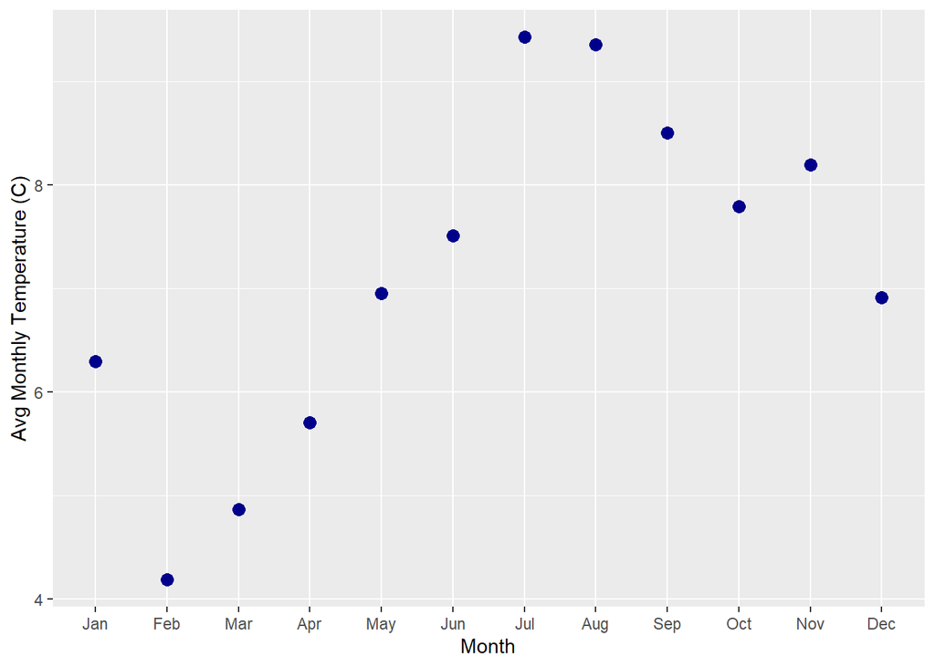

[figure not shown]

```r
library(dplyr)
library(ggplot2)
library(lubridate)

# clean up the NA data (NA's are = -99 or -999 depending on data col)
df <- mloa %>%
  filter(!rel_humid == -99, !temp_C_2m == -999.9, !windSpeed_m_s == -99.9) %>% #removing NAs
  mutate(mon=month(datetime, label = TRUE, abbr=TRUE), jday=yday(datetime)) #making new column where each month is named, and jday (days after Jan 1st) is calculated

df2 <- df %>%
  group_by(mon) %>%
  summarize(avg_temp_2m = mean(temp_C_2m)) #average monthly temperature

df2 %>%
  ggplot() +
  geom_point(aes(x=mon, y=avg_temp_2m), color="darkblue", size= 3)+
  ylab("Avg Monthly Temperature (C)") + xlab("Month")
```

## Example 2: Pressure Transducer (Solinst) Data Logger

Let’s practice with another data file, a logger that records water temperature and river stage every 15 minutes from the NF American River. You can download the file by right clicking on the webpage, or simply use the web URL. We’ve practiced both now. (The file is also available on the R-DAVIS website in the [Resources->Datasets](https://gge-ucd.github.io/R-DAVIS/resources.html) tab.)

*This dataset has 35,038 observations for water temperature, and stage (pressure transducer info).*

> First part of the challenge: Read in and assign the data to your environment using either the direct webpage URL, or the downloaded file.

```
##          Date             Time             ms        Level
##  2014/08/06:   96   00:00:00:  365   Min.   :0   Min.   :0.7718
##  2014/08/07:   96   00:15:00:  365   1st Qu.:0   1st Qu.:1.1190
##  2014/08/08:   96   00:30:00:  365   Median :0   Median :1.3135
##  2014/08/09:   96   00:45:00:  365   Mean   :0   Mean   :1.3791
##  2014/08/10:   96   01:00:00:  365   3rd Qu.:0   3rd Qu.:1.5235
##  2014/08/11:   96   01:15:00:  365   Max.   :0   Max.   :4.7376
##  (Other)   :34462   (Other) :32848
##   Temperature
##  Min.   : 1.724
##  1st Qu.: 8.197
##  Median :13.258
##  Mean   :14.291
##  3rd Qu.:20.960
##  Max.   :28.748
##
```

```
## [1] "Date"        "Time"        "ms"          "Level"       "Temperature"
```

### Challenge

> - Make a `datetime` column and format as `POSIXct`
> - Calculate Weekly **Mean, Max, Min** Water Temperatures and plot as point or line plot *(HINT: `dplyr` function)*
> - Calculate Hourly mean **Level** for April through June and make a line plot (using `ggplot2`).
> - Make a ggplot geom_pointrange plot of the avg. max, min monthly temperatures.

**Solutions**

```
##         Date     Time ms  Level Temperature            datetime   yr mon
## 1 2014/08/05 11:00:00  0 0.8245      23.069 2014-08-05 11:00:00 2014   8
## 2 2014/08/05 11:15:00  0 1.1457      22.023 2014-08-05 11:15:00 2014   8
## 3 2014/08/05 11:30:00  0 1.1485      22.030 2014-08-05 11:30:00 2014   8
## 4 2014/08/05 11:45:00  0 1.1482      22.035 2014-08-05 11:45:00 2014   8
## 5 2014/08/05 12:00:00  0 1.1504      22.033 2014-08-05 12:00:00 2014   8
## 6 2014/08/05 12:15:00  0 1.1495      22.028 2014-08-05 12:15:00 2014   8
##   wk DOY hr
## 1 31 217 11
## 2 31 217 11
## 3 31 217 11
## 4 31 217 11
## 5 31 217 12
## 6 31 217 12
```

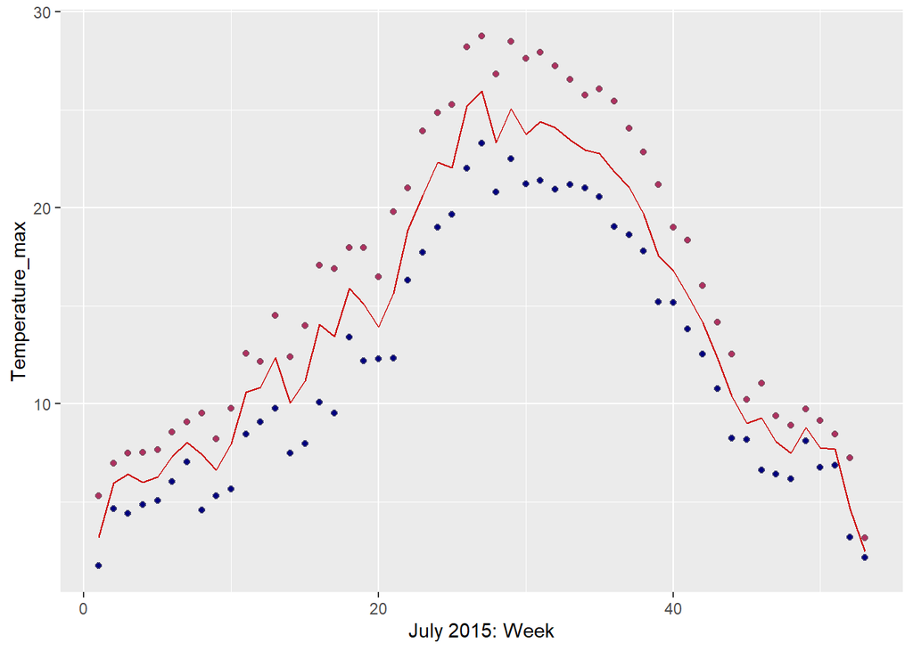

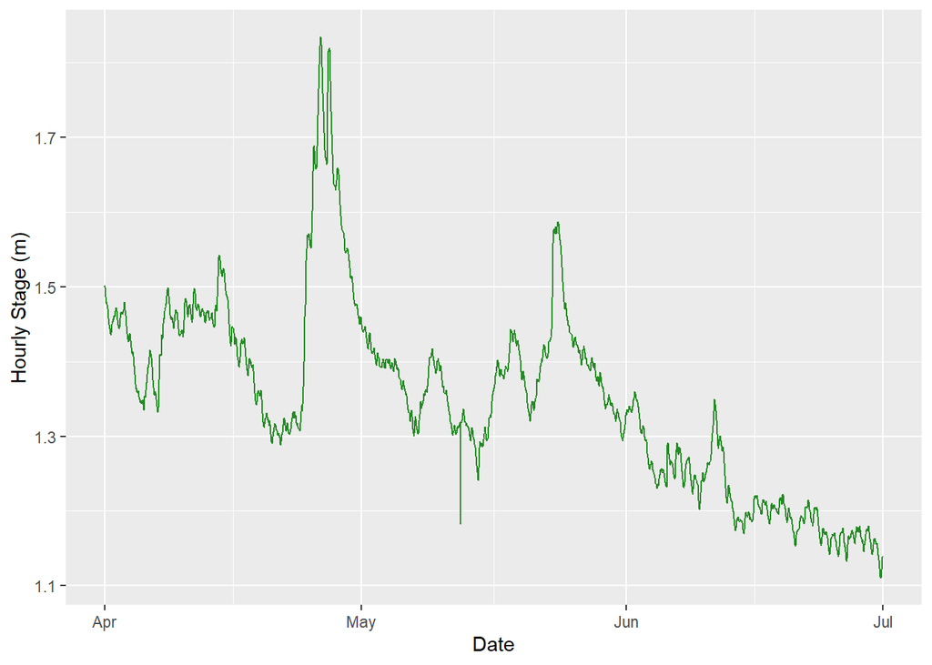

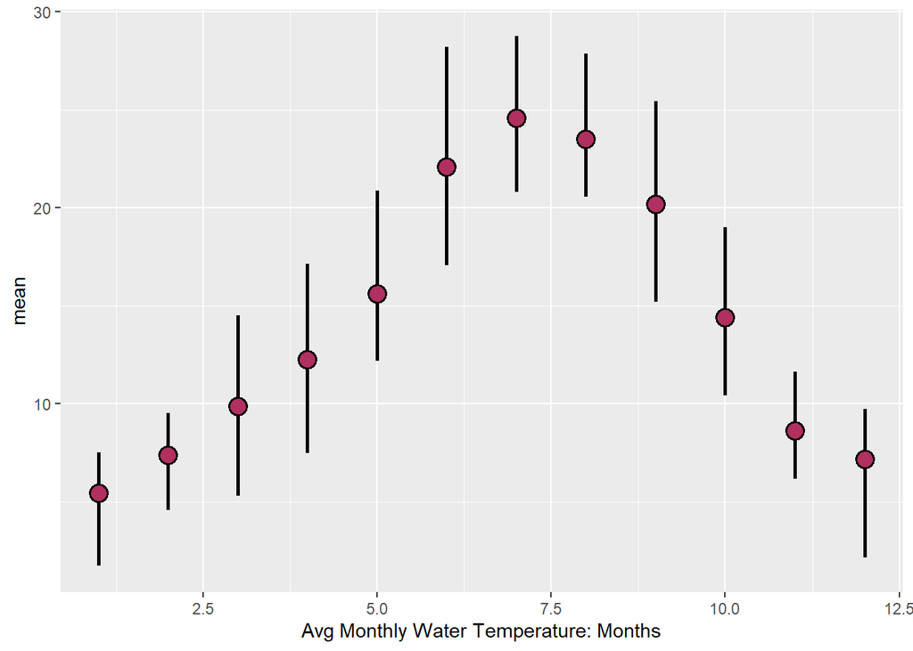

This lesson was contributed by [Ryan Peek](https://ryanpeek.github.io/).